# IODS course project

Sampsa Huttunen

# About the Course

This course is about R, the use of Github, and data analysis. Maybe not exactly an exhaustive description of the course, but along those lines.

[My Github Repository](http://github.com/huttusam/IODS-project)

## Some Links

[My Course Diary](http://huttusam.github.io/IODS-project)  
[R Markdown Cheatsheet](http://www.rstudio.com/wp-content/uploads/2015/02/rmarkdown-cheatsheet.pdf)  
[Introduction to Open Data Science - Course Web Page](http://mooc.helsinki.fi/course/view.php?id=52)

# Regression and model validation

### Data Wrangling

##### I have created a new dataset named ‘analysis_dataset’ from the dataset ‘JYTOPKYS3_data’.

##### Data Files:

- The original dataset (JYTOPKYS3-data.txt) can be found [here](http://www.helsinki.fi/~kvehkala/JYTmooc/JYTOPKYS3-data.txt)
- The new dataset (analysis_dataset.csv) can be found [here](https://github.com/huttusam/IODS-project/blob/master/data/analysis_dataset.csv)

##### Script:

- The R script used to create the new dataset (*with comments explaining the process*) is [here](https://github.com/huttusam/IODS-project/blob/master/data/create_learning2014.R)

### Analysis

#### Exercise 1

The original dataset contains answers to a survey conducted to the participants of an introductory Statistics course; n=166 (66% female, mean age 25.51 years, SD = 7.8).  
The following variables were chosen to ‘analysis_dataset’ for further analysis:

- *gender* (F/M)
- *age* (in years)
- *attitude*: an average of answers to 10 questions measuring the student’s attitude towards Statistics (Likert scale)
- *deep*: an average of answers to 12 questions measuring the student’s level of deep learning approach (Likert scale)
- *stra*: an average of answers to 8 questions measuring the student’s level of strategic learning approach (Likert scale)
- *surf*: an average of answers to 12 questions measuring the student’s level of surface learning approach (Likert scale)
- *points*: the student’s exam score.

##### Notes:

- In the original dataset the variable ‘attitude’ was a sum of 10 Likert scale values. In the new dataset, the value ‘attitude’ has been changed back to average by dividing the values by 10.
- Observations in the original data, where the exam score (*points*) was 0, have been omitted from the new dataset.

#### Exercise 2

From a scatter plot matrix formed from the data in ‘analysis_dataset’, we can see that the age structure of the students is fairly young, most likely due to the fact that they are university students. Students’ attitude towards Statistics (*attitude*) correlates (r=0.437) with students’ exam results (*points*), which is not very surprising either. If you like what you study, you tend to get better grades. The same goes with the negative correlation (r=-0.324) between surface and deep learning approaches. Using one more means that you probably use the other less.

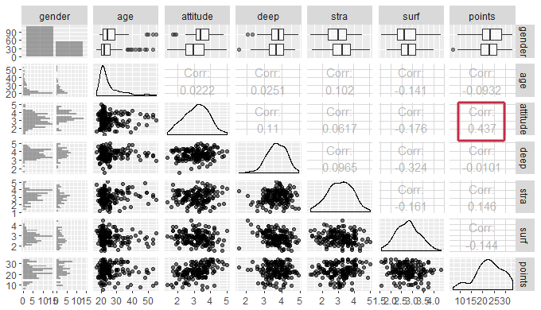

When male and female students are looked at separately, we can see that the attitude towards Statistics seems to be a bit more positive among the male than female students. Also, female students seem to use the surface learning approach slightly more than male students.

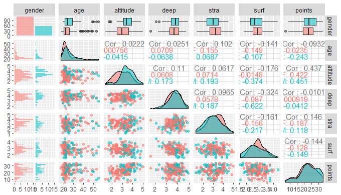

When we create a regression model of *attitude* versus *points*, we can see the correlation between them more clearly.

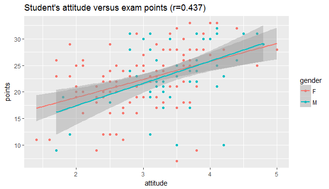

#### Exercise 3 & 4

When we choose *attitude*, *surf* and *strat* as explanatory variables and fit a regression model where exam result (*points*) is the target (dependent) variable, we get the following results:

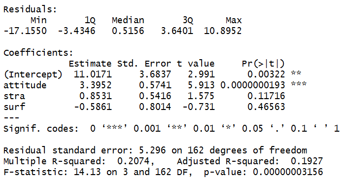

Looking at the values, we can see that *surf* has no statistically significant realtionship with the target variable (*points*). Taking *surf* out of the model produces the following results:

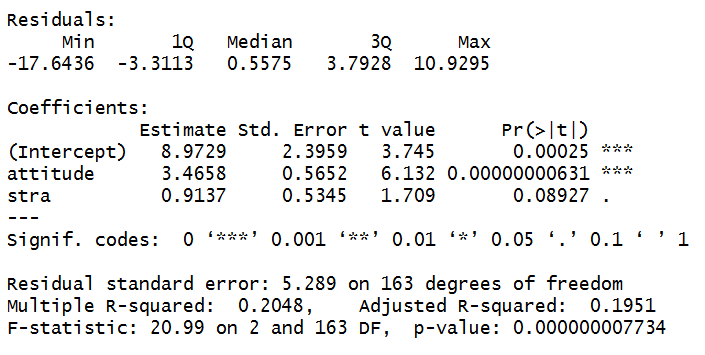

Multiple R Squared (Finnish: *selityskerroin*):  
The higher the value, the better the independent variables predict the dependent variable. In the above cases, where the R squared is ~ 0,2, the independent variables can explain about 20% of the variation of the dependant variable.

#### Exercise 5

The required diagnostic plots, Residuals vs Fitted values, Normal QQ-plot and Residuals vs Leverage, are below. With these plots, the validity of the model can be assessed. The first plot (Residuals vs. Fitted) shows that there are no problems in the model, since the reasonably flat line indicates that the linear model is working. In the second plot (Normal Q-Q) the linearity of the points suggests that the data is normally distributed. The third plot (Residuals vs. Leverage) shows that the data has no outliers that would skew the regression results.

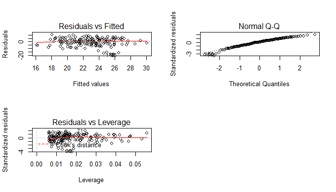

# Logistic Regression

### Data Wrangling

##### I have created a new dataset ‘alcohol-joined’ from two datasets of alcohol use habits and background info of Math and Portugese language course students, n=382 (198 females and 184 males, mean age of 16.6 years).

##### Data Files:

- The original datasets are student-mat.csv and student-por.csv
- The new dataset is alcohol-joined.csv

##### Script:

- The R script used to create the new dataset (*with comments explaining the process*) is create_alc.R

### Analysis

The new dataset ‘alc’ has 382 observations and 35 variables. The variables are:

```r
alc = read.table("data/alcohol-joined.csv", sep = ";", header = TRUE)
colnames(alc)
```

```
##  [1] "school"     "sex"        "age"        "address"    "famsize"
##  [6] "Pstatus"    "Medu"       "Fedu"       "Mjob"       "Fjob"
## [11] "reason"     "nursery"    "internet"   "guardian"   "traveltime"
## [16] "studytime"  "failures"   "schoolsup"  "famsup"     "paid"
## [21] "activities" "higher"     "romantic"   "famrel"     "freetime"
## [26] "goout"      "Dalc"       "Walc"       "health"     "absences"
## [31] "G1"         "G2"         "G3"         "alc_use"    "high_use"
```

##### The meaning of each variable is as follows:

- 1 school - student’s school (binary: ‘GP’ - Gabriel Pereira or ‘MS’ - Mousinho da Silveira)
- 2 sex - student’s sex (binary: ‘F’ - female or ‘M’ - male)
- 3 age - student’s age (numeric: from 15 to 22)
- 4 address - student’s home address type (binary: ‘U’ - urban or ‘R’ - rural)
- 5 famsize - family size (binary: ‘LE3’ - less or equal to 3 or ‘GT3’ - greater than 3)
- 6 Pstatus - parent’s cohabitation status (binary: ‘T’ - living together or ‘A’ - apart)
- 7 Medu - mother’s education (numeric: 0 - none, 1 - primary education (4th grade), 2 - 5th to 9th grade, 3 - secondary education or 4 - higher education)
- 8 Fedu - father’s education (numeric: 0 - none, 1 - primary education (4th grade), 2 - 5th to 9th grade, 3 - secondary education or 4 - higher education)
- 9 Mjob - mother’s job (nominal: ‘teacher’, ‘health’ care related, civil ‘services’ (e.g. administrative or police), ‘at_home’ or ‘other’)
- 10 Fjob - father’s job (nominal: ‘teacher’, ‘health’ care related, civil ‘services’ (e.g. administrative or police), ‘at_home’ or ‘other’)
- 11 reason - reason to choose this school (nominal: close to ‘home’, school ‘reputation’, ‘course’ preference or ‘other’)
- 12 guardian - student’s guardian (nominal: ‘mother’, ‘father’ or ‘other’)
- 13 traveltime - home to school travel time (numeric: 1 - <15 min., 2 - 15 to 30 min., 3 - 30 min. to 1 hour, or 4 - >1 hour)
- 14 studytime - weekly study time (numeric: 1 - <2 hours, 2 - 2 to 5 hours, 3 - 5 to 10 hours, or 4 - >10 hours)
- 15 failures - number of past class failures (numeric: n if 1<=n<3, else 4)
- 16 schoolsup - extra educational support (binary: yes or no)
- 17 famsup - family educational support (binary: yes or no)
- 18 paid - extra paid classes within the course subject (Math or Portuguese) (binary: yes or no)
- 19 activities - extra-curricular activities (binary: yes or no)
- 20 nursery - attended nursery school (binary: yes or no)
- 21 higher - wants to take higher education (binary: yes or no)
- 22 internet - Internet access at home (binary: yes or no)
- 23 romantic - with a romantic relationship (binary: yes or no)
- 24 famrel - quality of family relationships (numeric: from 1 - very bad to 5 - excellent)
- 25 freetime - free time after school (numeric: from 1 - very low to 5 - very high)
- 26 goout - going out with friends (numeric: from 1 - very low to 5 - very high)
- 27 Dalc - workday alcohol consumption (numeric: from 1 - very low to 5 - very high)
- 28 Walc - weekend alcohol consumption (numeric: from 1 - very low to 5 - very high)
- 29 health - current health status (numeric: from 1 - very bad to 5 - very good)
- 30 absences - number of school absences (numeric: from 0 to 93)

…and then there are the student’s grades that are averages of her Mathematics and Portugese language grades:

- 31 G1 - first period grade (numeric: from 0 to 20)
- 32 G2 - second period grade (numeric: from 0 to 20)
- 33 G3 - final grade (numeric: from 0 to 20, output target)

…the new variables, I have created in the data wrangling are:

- 34 alc_use - the average of workday and weekend alcohol consumption (numeric: from 1 - very low to 5 - very high)
- 35 high_use - if alc_use is more than 2, then TRUE else FALSE (binary: TRUE or FALSE)

### Relationship of alcohol consumption to other variables

Let’s look at a graphical summarization of the data:

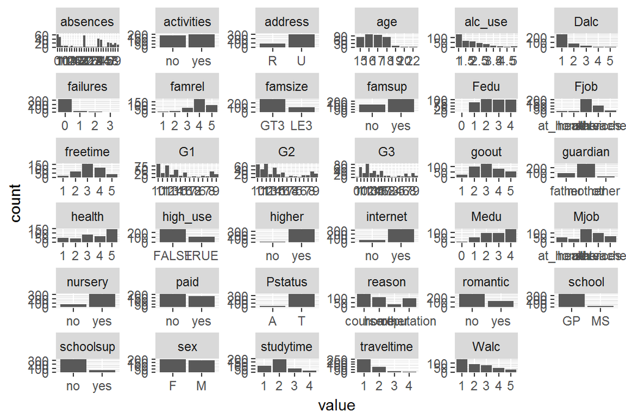

```r
# access the tidyverse libraries tidyr, dplyr, ggplot2
library(tidyverse);
# draw a bar plot of each variable
gather(alc) %>% ggplot(aes(value)) + facet_wrap("key", scales = "free") + geom_bar()
```

Interegsting variables to look at, considering their relation to alcohol consumption, would be, for example, sex, health, absences from classes and final grades. My hypothesis would be that men use more alcohol than women and that high alcohol consumption correlates with lower grades, more abscence and lower health status.

OK, let’s see how the aformentioned four variables correlate with alcohol consumption by cross tabulating them and drawing some plots to illustrate these correlations:

```r
# produce summary statistics by sex and mean alcohol use
alc %>% group_by(sex) %>% summarise(count = n(), mean_alcuse = mean(alc_use))
```

```
## # A tibble: 2 × 3
##      sex count mean_alcuse
##   <fctr> <int>       <dbl>
## 1      F   198    1.623737
## 2      M   184    2.173913
```

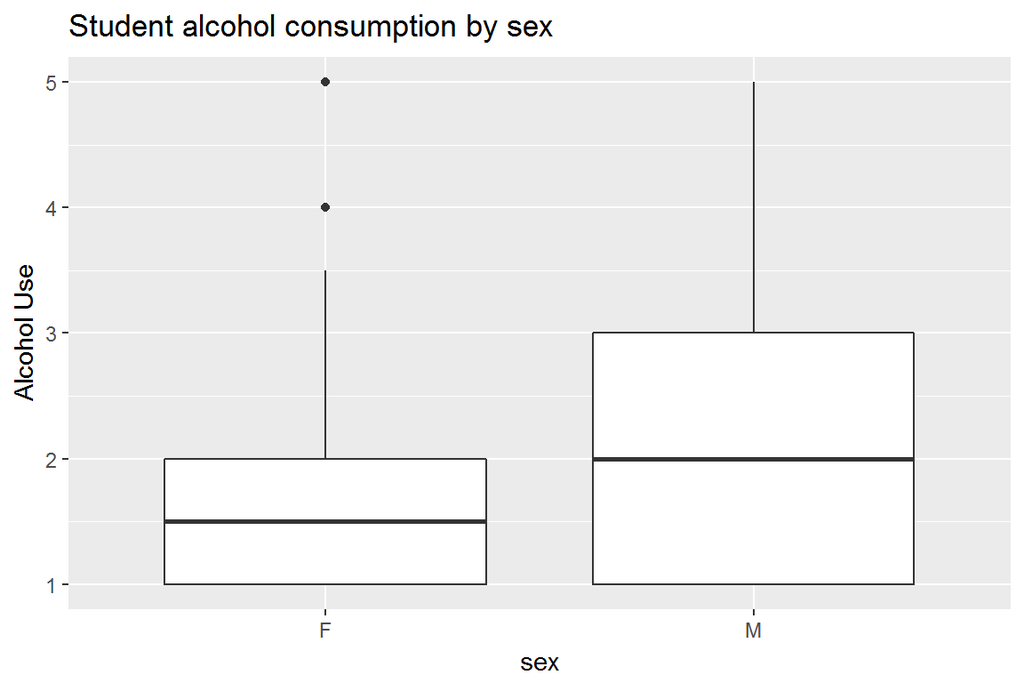

```r
# initialise a plot of sex and alc_use
g1 <- ggplot(alc, aes(x = sex, y = alc_use))

# define the plot as a boxplot and draw it
g1 + geom_boxplot() + ylab("Alcohol Use") + ggtitle("Student alcohol consumption by sex")
```

```r
# produce summary statistics by high_use and mean final grade
alc %>% group_by(high_use) %>% summarise(mean_grade = mean(G3))
```

```
## # A tibble: 2 × 2
##   high_use mean_grade
##      <lgl>      <dbl>
## 1    FALSE   11.73507
## 2     TRUE   10.80702
```

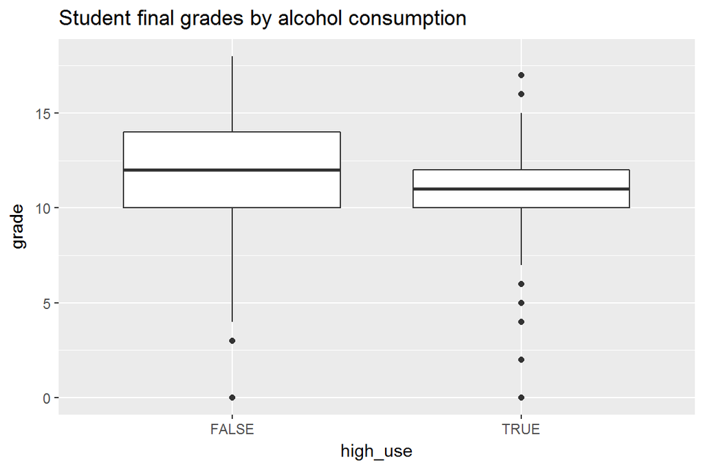

```r
# initialize a plot of high_use and G3
g2 <- ggplot(alc, aes(x = high_use, y = G3))

# define the plot as a boxplot and draw it
g2 + geom_boxplot() + ylab("grade") + ggtitle("Student final grades by alcohol consumption")
```

```r
# produce summary statistics by high_use and mean absences
alc %>% group_by(high_use) %>% summarise(mean_abs = mean(absences))
```

```
## # A tibble: 2 × 2
##   high_use mean_abs
##      <lgl>    <dbl>
## 1    FALSE 3.705224
## 2     TRUE 6.368421
```

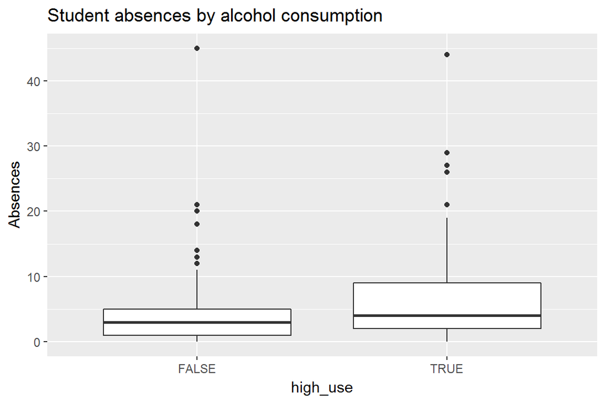

```r
# initialise a plot of high_use and absences
g3 <- ggplot(alc, aes(x = high_use, y = absences))

# define the plot as a boxplot and draw it
g3 + geom_boxplot() + ylab("Absences") + ggtitle("Student absences by alcohol consumption")
```

```r
# produce summary statistics by high_use and health
alc %>% group_by(high_use) %>% summarise(mean_health = mean(health))
```

```
## # A tibble: 2 × 2
##   high_use mean_health
##      <lgl>       <dbl>
## 1    FALSE    3.518657
## 2     TRUE    3.701754
```

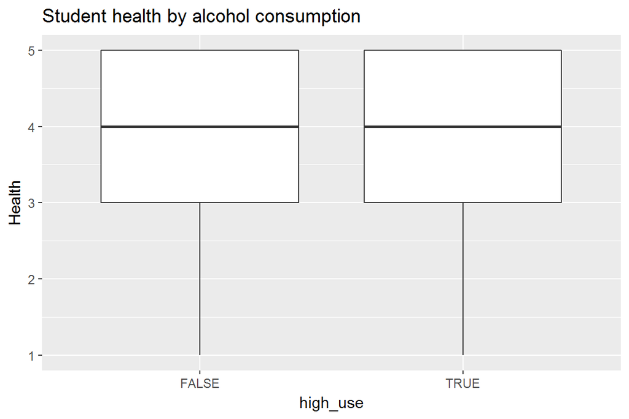

```r
# initialise a plot of high_use and health
g4 <- ggplot(alc, aes(x = high_use, y = health))

# define the plot as a boxplot and draw it
g4 + geom_boxplot() + ylab("Health") + ggtitle("Student health by alcohol consumption")
```

By looking at the cross-tabulaions and graphical presentations above, we can see that male students report bigger alcohol consumption than their female peers. High alcohol use also seems to correlate slightly with lower final grades and more absences from classes. On the other hand, alcohol use does not seem to correlate with health, but we have to keep in mind that the participants of this study are very young (15-22 year olds, mean age 16.6 years) and health problems created by alcohol mostly accumulate over time.

### Logistical regression analysis

Next we fit a logistic regression model to explain high consumption of alcohol.

```r
# find the model with glm()
m <- glm(high_use ~ G3 + absences + health + sex, data = alc, family = "binomial")
```

The summary of our fitted model is

```r
# print out a summary of the model
summary(m)
```

```
##
## Call:
## glm(formula = high_use ~ G3 + absences + health + sex, family = "binomial",
##     data = alc)
##
## Deviance Residuals:
##     Min       1Q   Median       3Q      Max
## -2.2762  -0.8492  -0.6146   1.0864   2.1396
##
## Coefficients:
##             Estimate Std. Error z value Pr(>|z|)
## (Intercept) -1.12067    0.57069  -1.964   0.0496 *
## G3          -0.07427    0.03584  -2.072   0.0382 *
## absences     0.09277    0.02303   4.028 5.62e-05 ***
## health       0.04026    0.08742   0.460   0.6452
## sexM         0.96946    0.24325   3.985 6.74e-05 ***
## ---
## Signif. codes:  0 '***' 0.001 '**' 0.01 '*' 0.05 '.' 0.1 ' ' 1
##
## (Dispersion parameter for binomial family taken to be 1)
##
##     Null deviance: 465.68  on 381  degrees of freedom
## Residual deviance: 425.30  on 377  degrees of freedom
## AIC: 435.3
##
## Number of Fisher Scoring iterations: 4
```

… and the coefficients of the model as odds ratios with confidence intervals is

```r
# compute odds ratios (OR)
OR <- coef(m) %>% exp

# compute confidence intervals (CI)
CI = exp(confint(m))

# print out the odds ratios with their confidence intervals
cbind(OR, CI)
```

```
##                    OR     2.5 %    97.5 %
## (Intercept) 0.3260597 0.1046920 0.9862794
## G3          0.9284223 0.8648509 0.9957691
## absences    1.0972091 1.0509220 1.1503430
## health      1.0410775 0.8780964 1.2380464
## sexM        2.6365084 1.6462472 4.2800640
```

When we look at the above printout, we can see that final grades, amount of absences and gender can be used to predict the likelihood of high alcohol consumption reasonably well: lower grades, more absences, and being male increase the possibility of high alcohol use. On the other hand, health status doesn’t seem to correlate with high alcohol use, which might be due to young age of participants.

### Predictive Power of the Model

Using the variables which, according to our logistic regression model, have a statistical relationship with alcohol consumption, let’s perform a 2x2 cross tabulation of predictions versus the actual values and visualize both the actual values and predictions graphically.

```r
# predict the probability of high alcohol use
probabilities <- predict(m, type = "response")

# add the predicted probabilities to 'alc'
alc <- mutate(alc, probability = probabilities)

# use probabilities to predict high alcohol use
alc <- mutate(alc, prediction = probability > 0.5)

# tabulate target variable vs predictions
table(high_use = alc$high_use, prediction = alc$prediction)
```

```
##         prediction
## high_use FALSE TRUE
##    FALSE   256   12
##    TRUE     87   27
```

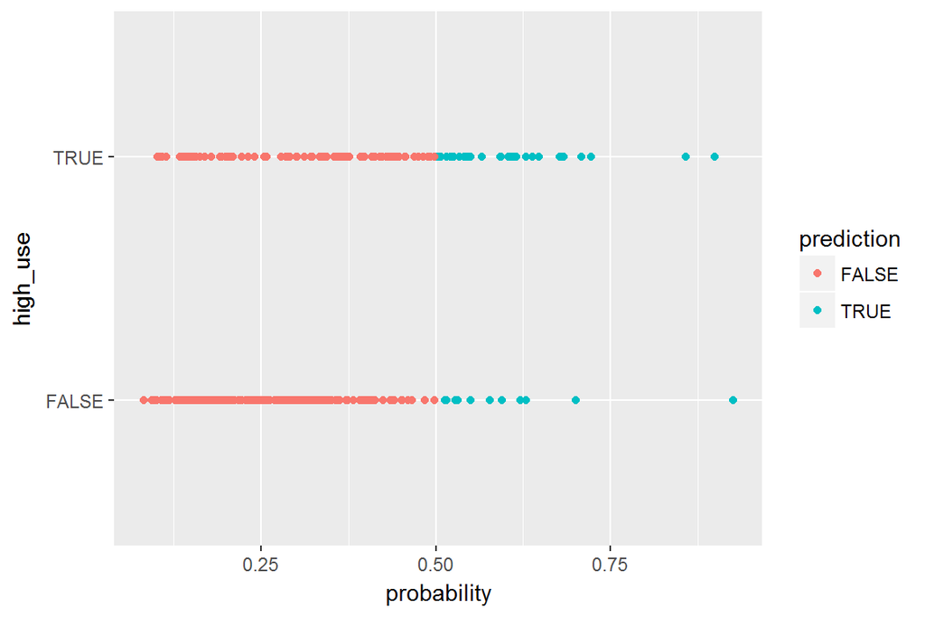

```r
# initialize a plot of high_use vs. probability
g <- ggplot(alc, aes(x = probability, y = high_use, col=prediction))

# define the geom as points and draw the plot
g + geom_point()
```

Our model estimates that 87 participants would not be and 12 would be high users when actually the opposite was true. The model accurately identified 27 participants as high users and 256 as not. Our graph tries to visualize the same, although the amount of accurately predicted non-high users (n=256) and inaccurately predicted high users (n=87) look quite similar (see red/left side of graph).

Let’s now compute the total proportion of inaccurately classified observations (i.e. incorrect predicitions, training error):

```r
# define a loss function (mean prediction error)
loss_func <- function(class, prob) {
  n_wrong <- abs(class - prob) > 0.5
  mean(n_wrong)
}

# call loss_func to compute the average number of wrong predictions in the (training) data
loss_func(class = alc$high_use, prob = alc$probability)
```

```
## [1] 0.2591623
```

… and, as a BONUS, do a 10-fold cross-validation for our model:

```r
# K-fold cross-validation
library(boot)
cv <- cv.glm(data = alc, cost = loss_func, glmfit = m, K = 10)

# average number of wrong predictions in the cross validation
cv$delta[1]
```

```
## [1] 0.2670157
```

The training error of our model (0.26) is lower than if we were just to guess whether a person has high or low alcohol use.

The validation error in our 10-fold cross-validation is about the same as in the model introduced in DataCamp (high_use ~ failures + absences + sex), which suggests that our model does equally well as the DataCamp model.

On the other hand, if we were to change our independent variable G3 (grade) to goout (how much the person goes out with his/her friends), the predictive power of our model increases, as can be seen in this second cross-validation:

```r
# find the model with glm
m2 <- glm(high_use ~ goout + absences + health + sex, data = alc, family = "binomial")

# K-fold cross-validation
cv <- cv.glm(data = alc, cost = loss_func, glmfit = m2, K = 10)

# average number of wrong predictions in the cross validation
cv$delta[1]
```

```
## [1] 0.2251309
```

# Clustering and Classification

This exercise analyses data from the *Boston Dataset*, which is a dataset containing Housing Values of Boston, Massachusettes Suburbias.

```r
# access the MASS package
library(MASS)
# load the data
data("Boston")
```

The data has 506 observations and 14 variables

```
## [1] 506  14
```

and its data structure looks like this:

```
## 'data.frame':    506 obs. of  14 variables:
##  $ crim   : num  0.00632 0.02731 0.02729 0.03237 0.06905 ...
##  $ zn     : num  18 0 0 0 0 0 12.5 12.5 12.5 12.5 ...
##  $ indus  : num  2.31 7.07 7.07 2.18 2.18 2.18 7.87 7.87 7.87 7.87 ...
##  $ chas   : int  0 0 0 0 0 0 0 0 0 0 ...
##  $ nox    : num  0.538 0.469 0.469 0.458 0.458 0.458 0.524 0.524 0.524 0.524 ...
##  $ rm     : num  6.58 6.42 7.18 7 7.15 ...
##  $ age    : num  65.2 78.9 61.1 45.8 54.2 58.7 66.6 96.1 100 85.9 ...
##  $ dis    : num  4.09 4.97 4.97 6.06 6.06 ...
##  $ rad    : int  1 2 2 3 3 3 5 5 5 5 ...
##  $ tax    : num  296 242 242 222 222 222 311 311 311 311 ...
##  $ ptratio: num  15.3 17.8 17.8 18.7 18.7 18.7 15.2 15.2 15.2 15.2 ...
##  $ black  : num  397 397 393 395 397 ...
##  $ lstat  : num  4.98 9.14 4.03 2.94 5.33 ...
##  $ medv   : num  24 21.6 34.7 33.4 36.2 28.7 22.9 27.1 16.5 18.9 ...
```

##### The variables stand for:

- crim - per capita crime rate by town.
- zn - proportion of residential land zoned for lots over 25,000 sq.ft.
- indus - proportion of non-retail business acres per town.
- chas - Charles River dummy variable (= 1 if tract bounds river; 0 otherwise).
- nox - nitrogen oxides concentration (parts per 10 million).
- rm - average number of rooms per dwelling.
- age - proportion of owner-occupied units built prior to 1940.
- dis - weighted mean of distances to five Boston employment centres.
- rad - index of accessibility to radial highways.
- tax - full-value property-tax rate per $10,000.
- ptratio - pupil-teacher ratio by town.
- black - 1000(Bk - 0.63)<sup>2</sup> where Bk is the proportion of blacks by town.
- lstat - lower status of the population (percent).
- medv - median value of owner-occupied homes in $1000s.

##### The source of the date are

Harrison, D. and Rubinfeld, D.L. (1978) Hedonic prices and the demand for clean air. J. Environ. Economics and Management 5, 81â“102.  
Belsley D.A., Kuh, E. and Welsch, R.E. (1980) Regression Diagnostics. Identifying Influential Data and Sources of Collinearity. New York: Wiley.

##### Now, let’s print a summary of the data:

```
##       crim                zn             indus            chas
##  Min.   : 0.00632   Min.   :  0.00   Min.   : 0.46   Min.   :0.00000
##  1st Qu.: 0.08204   1st Qu.:  0.00   1st Qu.: 5.19   1st Qu.:0.00000
##  Median : 0.25651   Median :  0.00   Median : 9.69   Median :0.00000
##  Mean   : 3.61352   Mean   : 11.36   Mean   :11.14   Mean   :0.06917
##  3rd Qu.: 3.67708   3rd Qu.: 12.50   3rd Qu.:18.10   3rd Qu.:0.00000
##  Max.   :88.97620   Max.   :100.00   Max.   :27.74   Max.   :1.00000
##       nox               rm             age              dis
##  Min.   :0.3850   Min.   :3.561   Min.   :  2.90   Min.   : 1.130
##  1st Qu.:0.4490   1st Qu.:5.886   1st Qu.: 45.02   1st Qu.: 2.100
##  Median :0.5380   Median :6.208   Median : 77.50   Median : 3.207
##  Mean   :0.5547   Mean   :6.285   Mean   : 68.57   Mean   : 3.795
##  3rd Qu.:0.6240   3rd Qu.:6.623   3rd Qu.: 94.08   3rd Qu.: 5.188
##  Max.   :0.8710   Max.   :8.780   Max.   :100.00   Max.   :12.127
##       rad              tax           ptratio          black
##  Min.   : 1.000   Min.   :187.0   Min.   :12.60   Min.   :  0.32
##  1st Qu.: 4.000   1st Qu.:279.0   1st Qu.:17.40   1st Qu.:375.38
##  Median : 5.000   Median :330.0   Median :19.05   Median :391.44
##  Mean   : 9.549   Mean   :408.2   Mean   :18.46   Mean   :356.67
##  3rd Qu.:24.000   3rd Qu.:666.0   3rd Qu.:20.20   3rd Qu.:396.23
##  Max.   :24.000   Max.   :711.0   Max.   :22.00   Max.   :396.90
##      lstat            medv
##  Min.   : 1.73   Min.   : 5.00
##  1st Qu.: 6.95   1st Qu.:17.02
##  Median :11.36   Median :21.20
##  Mean   :12.65   Mean   :22.53
##  3rd Qu.:16.95   3rd Qu.:25.00
##  Max.   :37.97   Max.   :50.00
```

##### and visualize the data by printing its correlation matrix

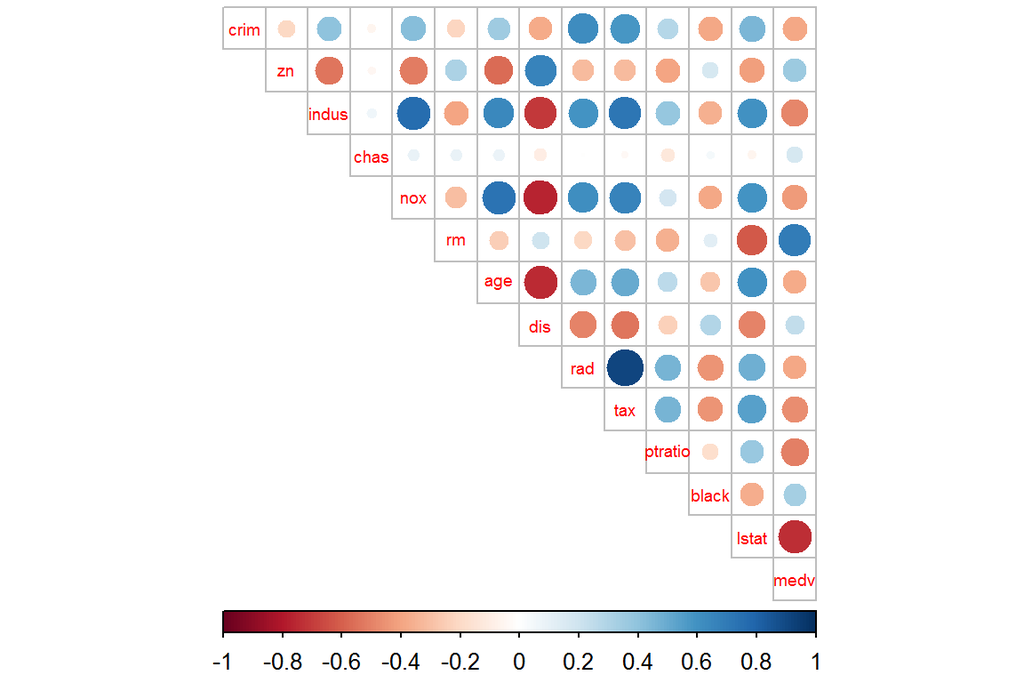

As we can see from the matrix, some variables have a strong positive (blue circles) or negative correlation (red circles). It appears, for example, that the area’s property-tax rate (tax) correaltes heavily with access to radial highways (rad). In ther words, the closer the highways, the bigger the tax.

The area’s distance from employment centres, on the other hand, has a strong negative correlation with the its  
a) number of older buildings  
b) nitrogen oxide levels  
c) proportion of non-retail business acres.

Another self-evident correlation in the data can be seen in the lower right corner of the matrix: Low socioeconomic status of the people living in the area (lstat) has a strong negative correlation with the median value of owner-occupied homes (medv). In other words, poorer people own less-valuable properties and vice versa.

##### Then we standardize the dataset and print out a summary:

```r
# center and standardize variables
boston_scaled <- scale(Boston)

# summaries of the scaled variables
summary(boston_scaled)
```

```
##       crim                 zn               indus
##  Min.   :-0.419367   Min.   :-0.48724   Min.   :-1.5563
##  1st Qu.:-0.410563   1st Qu.:-0.48724   1st Qu.:-0.8668
##  Median :-0.390280   Median :-0.48724   Median :-0.2109
##  Mean   : 0.000000   Mean   : 0.00000   Mean   : 0.0000
##  3rd Qu.: 0.007389   3rd Qu.: 0.04872   3rd Qu.: 1.0150
##  Max.   : 9.924110   Max.   : 3.80047   Max.   : 2.4202
##       chas              nox                rm               age
##  Min.   :-0.2723   Min.   :-1.4644   Min.   :-3.8764   Min.   :-2.3331
##  1st Qu.:-0.2723   1st Qu.:-0.9121   1st Qu.:-0.5681   1st Qu.:-0.8366
##  Median :-0.2723   Median :-0.1441   Median :-0.1084   Median : 0.3171
##  Mean   : 0.0000   Mean   : 0.0000   Mean   : 0.0000   Mean   : 0.0000
##  3rd Qu.:-0.2723   3rd Qu.: 0.5981   3rd Qu.: 0.4823   3rd Qu.: 0.9059
##  Max.   : 3.6648   Max.   : 2.7296   Max.   : 3.5515   Max.   : 1.1164
##       dis               rad               tax             ptratio
##  Min.   :-1.2658   Min.   :-0.9819   Min.   :-1.3127   Min.   :-2.7047
##  1st Qu.:-0.8049   1st Qu.:-0.6373   1st Qu.:-0.7668   1st Qu.:-0.4876
##  Median :-0.2790   Median :-0.5225   Median :-0.4642   Median : 0.2746
##  Mean   : 0.0000   Mean   : 0.0000   Mean   : 0.0000   Mean   : 0.0000
##  3rd Qu.: 0.6617   3rd Qu.: 1.6596   3rd Qu.: 1.5294   3rd Qu.: 0.8058
##  Max.   : 3.9566   Max.   : 1.6596   Max.   : 1.7964   Max.   : 1.6372
##      black             lstat              medv
##  Min.   :-3.9033   Min.   :-1.5296   Min.   :-1.9063
##  1st Qu.: 0.2049   1st Qu.:-0.7986   1st Qu.:-0.5989
##  Median : 0.3808   Median :-0.1811   Median :-0.1449
##  Mean   : 0.0000   Mean   : 0.0000   Mean   : 0.0000
##  3rd Qu.: 0.4332   3rd Qu.: 0.6024   3rd Qu.: 0.2683
##  Max.   : 0.4406   Max.   : 3.5453   Max.   : 2.9865
```

##### Now all our variables follow the same standard and are, thus, comparable to each other.

##### Let’s also convert the data to a data frame format for later use:

```r
# change the object to data frame
boston_scaled <- as.data.frame(boston_scaled)
```

##### Now, let’s create a categorical variable of the crime rate in the Boston dataset and delete the old crime rate variable

```r
# save the scaled crim as scaled_crim
scaled_crim <- boston_scaled$crim

# create a quantile vector of crim and print it
bins <- quantile(scaled_crim)

# create a categorical variable 'crime'
crime <- cut(scaled_crim, breaks = bins, include.lowest = TRUE, label=c("low", "med_low", "med_high", "high"))

# remove original crim from the dataset
boston_scaled <- dplyr::select(boston_scaled, -crim)

# add the new categorical value to scaled data
boston_scaled <- data.frame(boston_scaled, crime)
```

##### The summary of our dataset will now look like this with our new categorical crime variable as the last column.

```
##        zn               indus              chas              nox
##  Min.   :-0.48724   Min.   :-1.5563   Min.   :-0.2723   Min.   :-1.4644
##  1st Qu.:-0.48724   1st Qu.:-0.8668   1st Qu.:-0.2723   1st Qu.:-0.9121
##  Median :-0.48724   Median :-0.2109   Median :-0.2723   Median :-0.1441
##  Mean   : 0.00000   Mean   : 0.0000   Mean   : 0.0000   Mean   : 0.0000
##  3rd Qu.: 0.04872   3rd Qu.: 1.0150   3rd Qu.:-0.2723   3rd Qu.: 0.5981
##  Max.   : 3.80047   Max.   : 2.4202   Max.   : 3.6648   Max.   : 2.7296
##        rm               age               dis               rad
##  Min.   :-3.8764   Min.   :-2.3331   Min.   :-1.2658   Min.   :-0.9819
##  1st Qu.:-0.5681   1st Qu.:-0.8366   1st Qu.:-0.8049   1st Qu.:-0.6373
##  Median :-0.1084   Median : 0.3171   Median :-0.2790   Median :-0.5225
##  Mean   : 0.0000   Mean   : 0.0000   Mean   : 0.0000   Mean   : 0.0000
##  3rd Qu.: 0.4823   3rd Qu.: 0.9059   3rd Qu.: 0.6617   3rd Qu.: 1.6596
##  Max.   : 3.5515   Max.   : 1.1164   Max.   : 3.9566   Max.   : 1.6596
##       tax             ptratio            black             lstat
##  Min.   :-1.3127   Min.   :-2.7047   Min.   :-3.9033   Min.   :-1.5296
##  1st Qu.:-0.7668   1st Qu.:-0.4876   1st Qu.: 0.2049   1st Qu.:-0.7986
##  Median :-0.4642   Median : 0.2746   Median : 0.3808   Median :-0.1811
##  Mean   : 0.0000   Mean   : 0.0000   Mean   : 0.0000   Mean   : 0.0000
##  3rd Qu.: 1.5294   3rd Qu.: 0.8058   3rd Qu.: 0.4332   3rd Qu.: 0.6024
##  Max.   : 1.7964   Max.   : 1.6372   Max.   : 0.4406   Max.   : 3.5453
##       medv              crime
##  Min.   :-1.9063   low     :127
##  1st Qu.:-0.5989   med_low :126
##  Median :-0.1449   med_high:126
##  Mean   : 0.0000   high    :127
##  3rd Qu.: 0.2683
##  Max.   : 2.9865
```

##### Next, we are going to divide the dataset to train and test sets, so that 80% of the data belongs to the train set:

```r
# number of rows in the Boston dataset
n <- nrow(boston_scaled)

# choose randomly 80% of the rows
ind <- sample(n,  size = n * 0.8)

# create train set
train <- boston_scaled[ind,]

# create test set
test <- boston_scaled[-ind,]

# save the correct classes from test data
correct_classes <- test$crime
```

##### The summary of our training dataset will now look like this:

```
##        zn               indus               chas
##  Min.   :-0.48724   Min.   :-1.55630   Min.   :-0.27233
##  1st Qu.:-0.48724   1st Qu.:-0.84788   1st Qu.:-0.27233
##  Median :-0.48724   Median :-0.18028   Median :-0.27233
##  Mean   :-0.04616   Mean   : 0.04417   Mean   : 0.02003
##  3rd Qu.:-0.48724   3rd Qu.: 1.01499   3rd Qu.:-0.27233
##  Max.   : 3.58609   Max.   : 2.42017   Max.   : 3.66477
##       nox                 rm                age
##  Min.   :-1.46443   Min.   :-3.87641   Min.   :-2.333128
##  1st Qu.:-0.84525   1st Qu.:-0.57625   1st Qu.:-0.886356
##  Median :-0.14407   Median :-0.12899   Median : 0.325949
##  Mean   : 0.04074   Mean   :-0.03267   Mean   : 0.003934
##  3rd Qu.: 0.65850   3rd Qu.: 0.44920   3rd Qu.: 0.921888
##  Max.   : 2.72965   Max.   : 3.47325   Max.   : 1.116390
##       dis                rad                tax
##  Min.   :-1.26582   Min.   :-0.98187   Min.   :-1.31269
##  1st Qu.:-0.83128   1st Qu.:-0.63733   1st Qu.:-0.75495
##  Median :-0.33043   Median :-0.52248   Median :-0.37521
##  Mean   :-0.02604   Mean   : 0.04777   Mean   : 0.05293
##  3rd Qu.: 0.62827   3rd Qu.: 1.65960   3rd Qu.: 1.52941
##  Max.   : 3.95660   Max.   : 1.65960   Max.   : 1.79642
##     ptratio             black              lstat
##  Min.   :-2.70470   Min.   :-3.90333   Min.   :-1.52961
##  1st Qu.:-0.48756   1st Qu.: 0.18403   1st Qu.:-0.76397
##  Median : 0.29768   Median : 0.37670   Median :-0.15167
##  Mean   : 0.03998   Mean   :-0.01739   Mean   : 0.02871
##  3rd Qu.: 0.80578   3rd Qu.: 0.43462   3rd Qu.: 0.63008
##  Max.   : 1.63721   Max.   : 0.44062   Max.   : 3.54526
##       medv               crime
##  Min.   :-1.90634   low     :103
##  1st Qu.:-0.66954   med_low : 96
##  Median :-0.16123   med_high: 95
##  Mean   :-0.03201   high    :110
##  3rd Qu.: 0.26826
##  Max.   : 2.98650
```

##### And the summary of our test dataset like this:

```
##        zn              indus              chas               nox
##  Min.   :-0.4872   Min.   :-1.5155   Min.   :-0.27233   Min.   :-1.4040
##  1st Qu.:-0.4872   1st Qu.:-0.9124   1st Qu.:-0.27233   1st Qu.:-0.9900
##  Median :-0.4872   Median :-0.4368   Median :-0.27233   Median :-0.1959
##  Mean   : 0.1828   Mean   :-0.1750   Mean   :-0.07933   Mean   :-0.1614
##  3rd Qu.: 0.4132   3rd Qu.: 1.0150   3rd Qu.:-0.27233   3rd Qu.: 0.4341
##  Max.   : 3.8005   Max.   : 2.1155   Max.   : 3.66477   Max.   : 2.7296
##        rm                age                dis
##  Min.   :-2.72785   Min.   :-2.21589   Min.   :-1.19192
##  1st Qu.:-0.49619   1st Qu.:-0.81175   1st Qu.:-0.70265
##  Median :-0.07705   Median : 0.17141   Median :-0.07071
##  Mean   : 0.12939   Mean   :-0.01558   Mean   : 0.10313
##  3rd Qu.: 0.57907   3rd Qu.: 0.84196   3rd Qu.: 0.74906
##  Max.   : 3.55153   Max.   : 1.11639   Max.   : 2.57645
##       rad               tax              ptratio
##  Min.   :-0.9819   Min.   :-1.30676   Min.   :-2.51994
##  1st Qu.:-0.6373   1st Qu.:-0.78462   1st Qu.:-0.85708
##  Median :-0.5225   Median :-0.60068   Median : 0.04363
##  Mean   :-0.1892   Mean   :-0.20966   Mean   :-0.15834
##  3rd Qu.:-0.4076   3rd Qu.: 0.05348   3rd Qu.: 0.80578
##  Max.   : 1.6596   Max.   : 1.52941   Max.   : 1.26768
##      black              lstat              medv               crime
##  Min.   :-3.79204   Min.   :-1.4946   Min.   :-1.68888   low     :24
##  1st Qu.: 0.26101   1st Qu.:-0.8613   1st Qu.:-0.51188   med_low :30
##  Median : 0.39773   Median :-0.3113   Median :-0.09599   med_high:31
##  Mean   : 0.06886   Mean   :-0.1137   Mean   : 0.12680   high    :17
##  3rd Qu.: 0.43005   3rd Qu.: 0.3020   3rd Qu.: 0.50475
##  Max.   : 0.44062   Max.   : 3.4066   Max.   : 2.98650
```

##### Then we will fit the linear discriminant analysis on the train set using the categorical crime rate as the target variable and all the other variables as predictor variables:

```r
# linear discriminant analysis
lda.fit <- lda(crime ~ ., data = train)
lda.fit
```

```
## Call:
## lda(crime ~ ., data = train)
##
## Prior probabilities of groups:
##       low   med_low  med_high      high
## 0.2549505 0.2376238 0.2351485 0.2722772
##
## Group means:
##                  zn      indus        chas        nox           rm
## low       0.8354987 -0.8974859 -0.11943197 -0.8430878  0.428269229
## med_low  -0.1234545 -0.2664172 -0.02626030 -0.5578643 -0.166400206
## med_high -0.4132207  0.2526125  0.30787518  0.4223119  0.005509225
## high     -0.4872402  1.0169558 -0.05757815  1.0611930 -0.380535479
##                 age        dis        rad        tax     ptratio
## low      -0.8600996  0.8113251 -0.6863918 -0.7532222 -0.37903131
## med_low  -0.3594323  0.3735206 -0.5559813 -0.4459803 -0.04922769
## med_high  0.3704308 -0.3673808 -0.3895040 -0.2620400 -0.27556639
## high      0.8135840 -0.8640242  1.6397657  1.5152267  0.78268316
##                black        lstat        medv
## low       0.37749704 -0.755925681  0.50915240
## med_low   0.33769960 -0.078367304 -0.02168867
## med_high  0.07485715  0.004951338  0.13480605
## high     -0.77669245  0.877388075 -0.69182715
##
## Coefficients of linear discriminants:
##                   LD1         LD2         LD3
## zn       0.1110146816  0.81008966 -0.87604694
## indus   -0.0229014564 -0.35025673  0.29409024
## chas    -0.0057324665 -0.11983083  0.01827509
## nox      0.4187201682 -0.58231517 -1.33088081
## rm      -0.0009830876  0.01738762 -0.15360379
## age      0.2819869419 -0.21094502 -0.17580655
## dis     -0.0819590217 -0.33774090  0.33004419
## rad      3.1948684644  0.98746440 -0.22398219
## tax      0.0143061124 -0.18117326  0.80548690
## ptratio  0.1456998268  0.07180589 -0.24098401
## black   -0.1308661016  0.03036468  0.12301762
## lstat    0.1786474487 -0.28258569  0.56772878
## medv     0.0916412895 -0.42032641 -0.06568973
##
## Proportion of trace:
##    LD1    LD2    LD3
## 0.9555 0.0316 0.0128
```

##### Then we will draw the LDA (bi)plot from the data:

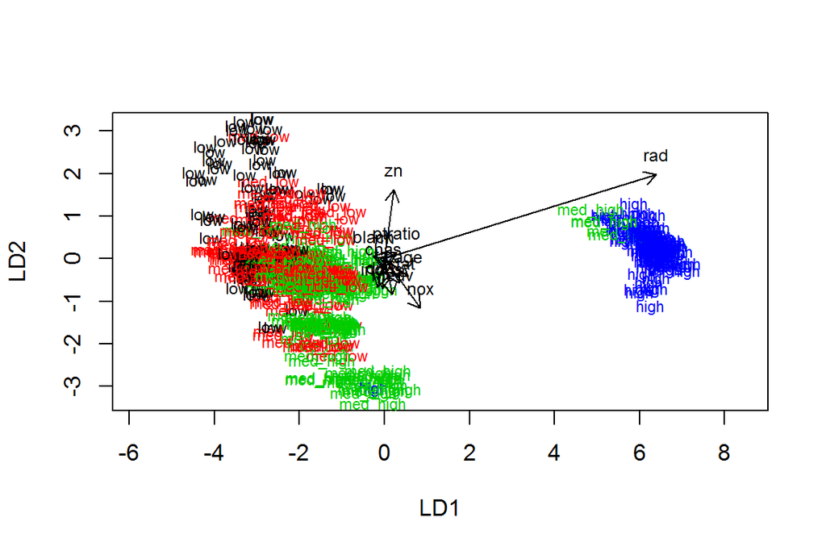

##### From the plot we can see that the closeness of radial highways strongly correlates with high crime rate.

##### Now, we save the crime categories from the test set and then remove the categorical crime variable from the test dataset:

```r
# save the correct classes from test data
correct_classes <- test$crime

# remove the crime variable from test data
test <- dplyr::select(test, -crime)
```

##### Next, We will predict the classes with the LDA model on the test data:

```r
# predict classes with test data
lda.pred <- predict(lda.fit, newdata = test)
```

##### Then we will cross tabulate the results with the crime categories from the test set:

```
##           predicted
## correct    low med_low med_high high
##   low       19       4        1    0
##   med_low   10      15        5    0
##   med_high   1      10       19    1
##   high       0       0        0   17
```

##### From the results we can see that our model predicts high crime rate quite well. Then, on the other hand, the model doesn’t do that well in other categories. In sum, if you want to know where the bad guys are, our model can help! :)

```r
# load MASS and Boston
library(MASS)
data('Boston')

# Scaling the variables
boston_scaled <- as.data.frame(boston_scaled)

# euclidean distance matrix
dist_eu <- dist(boston_scaled)

# look at the summary of the distances
summary(dist_eu)
```

```
##    Min. 1st Qu.  Median    Mean 3rd Qu.    Max.
##  0.1394  3.5270  4.9080  4.9390  6.2420 13.0000
```

##### Let’s now run a k-means algorithm on the dataset and investigate the optimal number of clusters and rerun the algorithm. After testing different amounts of clusters, I ended up with four, which gave me quite comprehensible visuals:

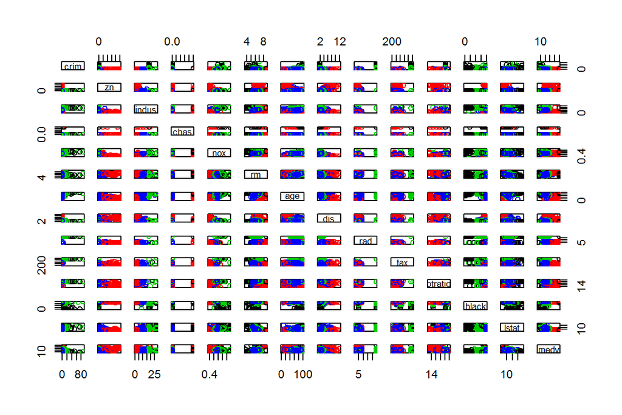

```r
# k-means clustering
km <- kmeans(dist_eu, centers = 4)

# plot the Boston dataset with clusters
pairs(Boston, col = km$cluster)
```